# Data Analysis To Identify Racial Disparity In Policing

**Part 5**

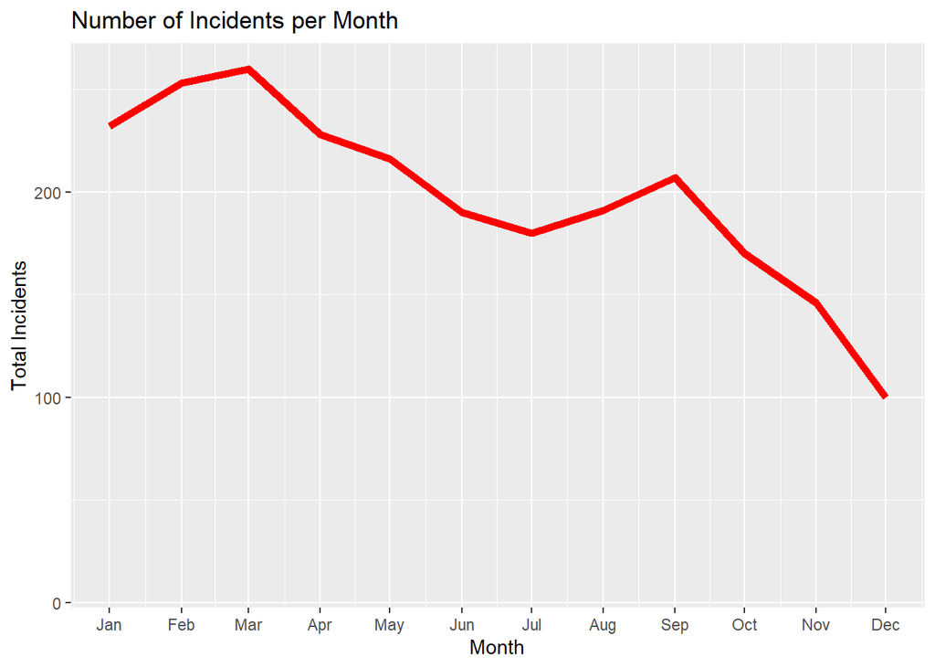

The time series plot above illustrates that during 2016, the police force recorded its highest number of incidents in March, our next plot will show a clearer trend with outliers taken into account

**Part 6**

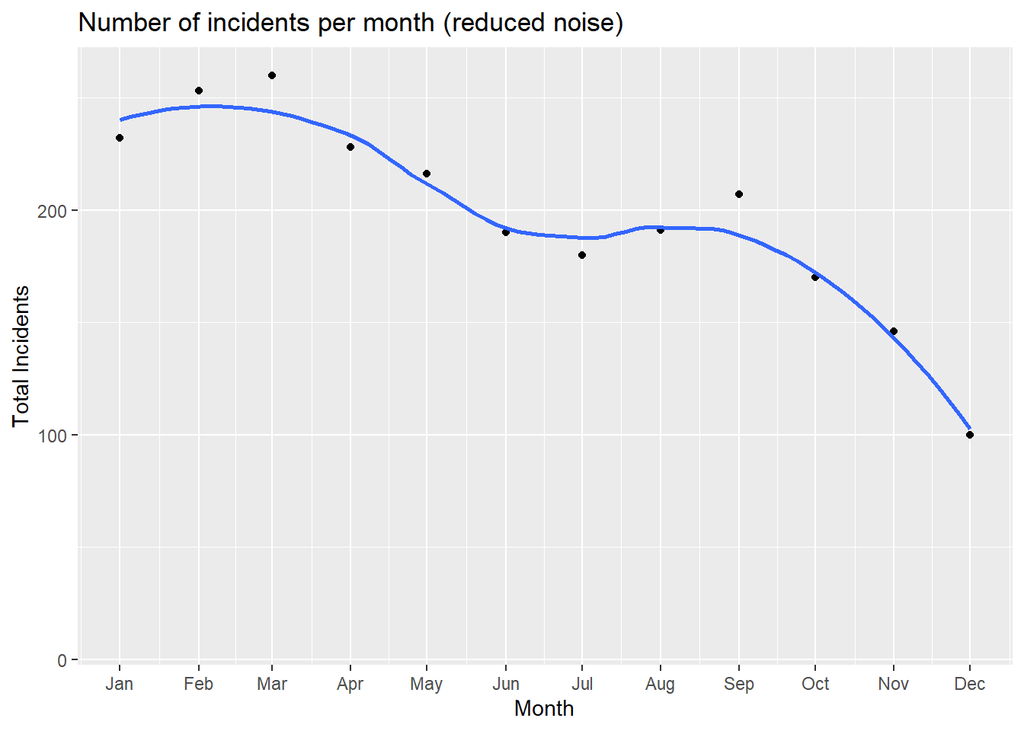

With smoothing applied to our time series plot, we see that actually the period between late january and to the middle of february were the highest points of recorded incidents. Overall the number of incidents seems to be declining, this isn’t necessarily a good thing however. It data just shows the inicdents that were actually responded to by the police. A dataset of the amount of crimes during that time would be ideal to show if progress was actually made.

**Part 7**

There correlation between the number of incidents that resulted in the subject being injured and the years of experience of an officer is -0.7615968. This strong negative correlation combined with the disporportionate amount of less experienced officers responding to incidents can prove to be deadly. The dallas police force needs to hire more officers with 10 or more years of experience.

**Part 8**

[interactive chart not shown]

The map above illustrates that downtown dallas has the majority of incidents leading to an officer getting injured. Police officers responding to incidents in this area should take extra precaution when dealing with the incident.

**Part 9**

[interactive chart not shown]

This interesting leaflet shows the areas where mentally unstable people were arrested. A closer inspection of the data reveals that these peole were likely to be near main roads and streets. This information suggests that this is were they are likely to be found. This can be used by the dallas police to take preventive measures by sweeping the roads and streets of mentally ill people and placing them in a hospital to get proper care, rather than wait for an incident to take place.

# Conclusion

In this report, we have identified several problem areas that need to be solved by the dallas police force. The data shows a pattern of lesser experienced officers (officers with less than 10 years of experience) tend to use excessive force on subjects , which is aggravated by the fact that these officers group are by a large margin the group who respond to the most incident cases. This means that subjects are more likely to be injured during an incident. Additionally we found that there is a decline in the number of female hires, which can lead to a diversity problem in the police workforce.

It is important to note that the analysis in this report is limited by incomplete data, which could impact the fact finding of this report. Despite the limitation, we are confident that action is needed to solve the aforementioned problem areas and improve the departments incident handling.

Overall, we implore the dallas police force to tackle this issues as soon as possible, because the lives of the people in their jurisdiction depend on their effective policing.[ref][2]

# References

Ref[1]: https://www.kaggle.com/datasets/center-for-policing-equity/data-science-for-good?datasetId=45286&sortBy=relevance&language=Python

Ref[2]: https://www.kaggle.com/code/linfaner2/acs-racism-index-and-policy-department-information